# Atividade-da-Aula-2

Bruna Mariz

01/04/2021

# Atividade da Aula 2

Passo a passo que me fizeram chegar até aqui:

1º Criar repositório do projeto no Github (Acessar conta no Github)

2º Criação do Projeto no RStudio (Abro o R; Sandbox - New projet; abre a acaixa de texto; escolho Version Control; Escolho Git; Preencho os capos do repositório com o link que fiz no Github; Aperto em criar)

3º Agora crio meu arquivo no RMarkdown (File; New File; Rmarkdown; Preencho o título)

4º Salvo o arquivo de trabalho no meu computador (clico no disquete e salvo na pasta que eu quero –> salvar arquivo na extensão rmt de Rmarkdown)

## Testando tutorial de introdução ao R da web

Nessa atividade escolhi um tutorial de introdução ao R encontrado no site http://ecovirtual.ib.usp.br/doku.php?id=ecovirt:roteiro:soft:rprincip

Escolhi esse tuturial por ter os comandos bem explicados e com exemplos nos chunks

Quero testar todos os comandos que eles fazem referência

obs. ```{r} sempre abre o chunk (primeira linha) e ’’’ fecha o chunk (última linha) –> se eu coloco algum comando junto as de abertura e fechamento do chunk, a afirmativa não é lida

As linhas de comando vão sempre ficar no chunk As respostas dos chunks vão estar no console (tela abaixo a esta) No console será repetido a operação do chunk (em azul) e a resposta ser logo abaixo em preto Sempre antes do resultado, aparece um [1]–> Isso é um contador (exemplo 1:100)

### Operações Aritméticas

O R faz operações matématicas desde o básico ao avançado. Em operações aritméticas, basta colocar o símbolo como se fosse na calculadora convencional

```r
2+2
```

```
## [1] 4
```

```r
5-1
```

```
## [1] 4
```

```r
2*3
```

```
## [1] 6
```

```r
4/5
```

```
## [1] 0.8
```

```r
      1:100 #demonstração que [1]é um contador --> a cada linha da sequência de 1 a 100 aparece [número em que inicia a linha]
```

```
##   [1]   1   2   3   4   5   6   7   8   9  10  11  12  13  14  15  16  17  18
##  [19]  19  20  21  22  23  24  25  26  27  28  29  30  31  32  33  34  35  36
##  [37]  37  38  39  40  41  42  43  44  45  46  47  48  49  50  51  52  53  54
##  [55]  55  56  57  58  59  60  61  62  63  64  65  66  67  68  69  70  71  72
##  [73]  73  74  75  76  77  78  79  80  81  82  83  84  85  86  87  88  89  90
##  [91]  91  92  93  94  95  96  97  98  99 100
```

### Operações com objetos

No R é possivel criar ou fazer referência a objetos. 1º Escolho um nome 2º Atribuo ao nome valor ou um conjunto de valores ou palavras 3º Se quiser que o objeto tenha mais de um elemento escrevo –> c(“elemento 1”, “elemento 2”)

```r
valor <- 5 #comando correto ... #comando errado se eu der espaço entre < -
pares <- c(0,2,4,6,8)
cores <- c("azul", "vermelho", "amarelo")
#ou posso usar = em vez de <-
valor = 5
pares = c(0,2,4,6,8)
cores = c("azul", "vermelho", "amarelo")
```

Obs. Quando usamos o símbolo “=” ou “<” seguido de “-” estamos criando objetos com um nome que aparece a esquerda e que contém alguns elementos (o que vem a direita do símbolo). Quando criamos um objeto, ele fica guardado na memória do R até que você feche o programa. Porém, os objetos criados ficam ocultos. Para ver a lista de arquivos ocultos basta dar o seguinte comando:

```r
ls()[pares[-1]] #correto ...  errado se eu colocar espaço entre o parentese
```

```
## [1] "pares" NA      NA      NA
```

```r
############### não consegui obter resultado esperado neste comando --> aparece várias afirmações quando coloco valor entre parenteses e inválido quando coloco pares
```

### Operações de jogo

Pode-se jogar com os dados no R. Funciona como? a cada vez que você roda uma amostra o R faz um sorteio..

```r
moeda <- c("cara","coroa")
moeda
```

```
## [1] "cara"  "coroa"
```

```r
sample(moeda,1)
```

```
## [1] "coroa"
```

```r
sample(moeda,1)
```

```
## [1] "coroa"
```

```r
sample(moeda,1)
```

```
## [1] "cara"
```

```r
sample(moeda,1)
```

```
## [1] "cara"
```

```r
dado <- c(1:6)
dado
```

```
## [1] 1 2 3 4 5 6
```

```r
sample(dado,1)
```

```
## [1] 2
```

```r
sample(dado,1)
```

```
## [1] 3
```

```r
sample(dado,1)
```

```
## [1] 4
```

### Matrizes

Transforma um conjunto de dados em uma matriz. Ele dispõe todos os valores de acordo com o tanto de linhas e colunas que você pedir. Por isso é importante que a dimensão da matrix comporte de fato seus dados ou utilize um comando que dê várias matrizes com seus dados.

```r
1:100
```

```
##   [1]   1   2   3   4   5   6   7   8   9  10  11  12  13  14  15  16  17  18
##  [19]  19  20  21  22  23  24  25  26  27  28  29  30  31  32  33  34  35  36
##  [37]  37  38  39  40  41  42  43  44  45  46  47  48  49  50  51  52  53  54
##  [55]  55  56  57  58  59  60  61  62  63  64  65  66  67  68  69  70  71  72
##  [73]  73  74  75  76  77  78  79  80  81  82  83  84  85  86  87  88  89  90
##  [91]  91  92  93  94  95  96  97  98  99 100
```

```r
matrix(1:100,nrow=20,ncol=5) #nrow define o número de linhas (20) e ncol o de colunas (5)
```

```
##       [,1] [,2] [,3] [,4] [,5]
##  [1,]    1   21   41   61   81
##  [2,]    2   22   42   62   82
##  [3,]    3   23   43   63   83
##  [4,]    4   24   44   64   84
##  [5,]    5   25   45   65   85
##  [6,]    6   26   46   66   86
##  [7,]    7   27   47   67   87
##  [8,]    8   28   48   68   88
##  [9,]    9   29   49   69   89
## [10,]   10   30   50   70   90
## [11,]   11   31   51   71   91
## [12,]   12   32   52   72   92
## [13,]   13   33   53   73   93
## [14,]   14   34   54   74   94
## [15,]   15   35   55   75   95
## [16,]   16   36   56   76   96
## [17,]   17   37   57   77   97
## [18,]   18   38   58   78   98
## [19,]   19   39   59   79   99
## [20,]   20   40   60   80  100
```

```r
array(1:100,dim=c(5,5,4)) # o argumento agora é dim... deve conter os valores de cada dimensão c('linha', 'colunas', 'matriz')--> O resultado aparece como fatias de um bolo, onde cada camada é uma matriz
```

```
## , , 1
##
##      [,1] [,2] [,3] [,4] [,5]
## [1,]    1    6   11   16   21
## [2,]    2    7   12   17   22
## [3,]    3    8   13   18   23
## [4,]    4    9   14   19   24
## [5,]    5   10   15   20   25
##
## , , 2
##
##      [,1] [,2] [,3] [,4] [,5]
## [1,]   26   31   36   41   46
## [2,]   27   32   37   42   47
## [3,]   28   33   38   43   48
## [4,]   29   34   39   44   49
## [5,]   30   35   40   45   50
##
## , , 3
##
##      [,1] [,2] [,3] [,4] [,5]
## [1,]   51   56   61   66   71
## [2,]   52   57   62   67   72
## [3,]   53   58   63   68   73
## [4,]   54   59   64   69   74
## [5,]   55   60   65   70   75
##
## , , 4
##
##      [,1] [,2] [,3] [,4] [,5]
## [1,]   76   81   86   91   96
## [2,]   77   82   87   92   97
## [3,]   78   83   88   93   98
## [4,]   79   84   89   94   99
## [5,]   80   85   90   95  100
```

### Objetos vázios

Nesse comando os objetos são vázios ou não uteis. Usamos NA –> não se aplica, ou seja, aquela posição não está sendo ocupada por nenhum valor

```r
a=rep(NA,10)
a
```

```
##  [1] NA NA NA NA NA NA NA NA NA NA
```

```r
b=matrix(NA,nrow=3,ncol=3)
b
```

```
##      [,1] [,2] [,3]
## [1,]   NA   NA   NA
## [2,]   NA   NA   NA
## [3,]   NA   NA   NA
```

```r
c=array(NA,dim=c(3,3,3))
c
```

```
## , , 1
##
##      [,1] [,2] [,3]
## [1,]   NA   NA   NA
## [2,]   NA   NA   NA
## [3,]   NA   NA   NA
##
## , , 2
##
##      [,1] [,2] [,3]
## [1,]   NA   NA   NA
## [2,]   NA   NA   NA
## [3,]   NA   NA   NA
##
## , , 3
##
##      [,1] [,2] [,3]
## [1,]   NA   NA   NA
## [2,]   NA   NA   NA
## [3,]   NA   NA   NA
```

Por que fazer isso? Depois preenchemos os lugares vazios com outros valores do nosso interesse

```r
a[1]=2
a
```

```
##  [1]  2 NA NA NA NA NA NA NA NA NA
```

```r
a[1]
```

```
## [1] 2
```

```r
b[3,3]="oi"
b
```

```
##      [,1] [,2] [,3]
## [1,] NA   NA   NA
## [2,] NA   NA   NA
## [3,] NA   NA   "oi"
```

```r
b[2,2]="oi"
b
```

```
##      [,1] [,2] [,3]
## [1,] NA   NA   NA
## [2,] NA   "oi" NA
## [3,] NA   NA   "oi"
```

```r
b[1,1]="oi"
b
```

```
##      [,1] [,2] [,3]
## [1,] "oi" NA   NA
## [2,] NA   "oi" NA
## [3,] NA   NA   "oi"
```

```r
b[3,3]
```

```
## [1] "oi"
```

```r
c[3,3,1]="oi"
c
```

```
## , , 1
##
##      [,1] [,2] [,3]
## [1,] NA   NA   NA
## [2,] NA   NA   NA
## [3,] NA   NA   "oi"
##
## , , 2
##
##      [,1] [,2] [,3]
## [1,] NA   NA   NA
## [2,] NA   NA   NA
## [3,] NA   NA   NA
##
## , , 3
##
##      [,1] [,2] [,3]
## [1,] NA   NA   NA
## [2,] NA   NA   NA
## [3,] NA   NA   NA
```

```r
c[3,3,2]="ai"
c
```

```
## , , 1
##
##      [,1] [,2] [,3]
## [1,] NA   NA   NA
## [2,] NA   NA   NA
## [3,] NA   NA   "oi"
##
## , , 2
##
##      [,1] [,2] [,3]
## [1,] NA   NA   NA
## [2,] NA   NA   NA
## [3,] NA   NA   "ai"
##
## , , 3
##
##      [,1] [,2] [,3]
## [1,] NA   NA   NA
## [2,] NA   NA   NA
## [3,] NA   NA   NA
```

```r
c[3,3,3]="ui"
c
```

```
## , , 1
##
##      [,1] [,2] [,3]
## [1,] NA   NA   NA
## [2,] NA   NA   NA
## [3,] NA   NA   "oi"
##
## , , 2
##
##      [,1] [,2] [,3]
## [1,] NA   NA   NA
## [2,] NA   NA   NA
## [3,] NA   NA   "ai"
##
## , , 3
##
##      [,1] [,2] [,3]
## [1,] NA   NA   NA
## [2,] NA   NA   NA
## [3,] NA   NA   "ui"
```

```r
c[3,3,3]
```

```
## [1] "ui"
```

obs. Os comandos acima servem para indexar também.. ou seja, dizem a posição de um objeto. Quando coloco a em seguida a posição do valor da matriz entre colchetes (nome [posição]).

Se for a matriz c (tridimensional) coloco –> nome[número da linha, número da coluna, número da fatia do bolo]

### Gráficos

Segue abaixo vários tipos de gráficos: Linear Histograma Boxplot

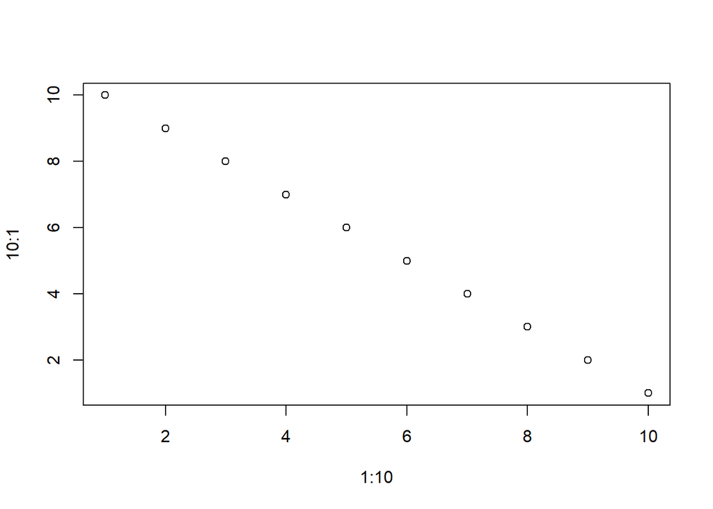

```r
plot(1:10,10:1)
```

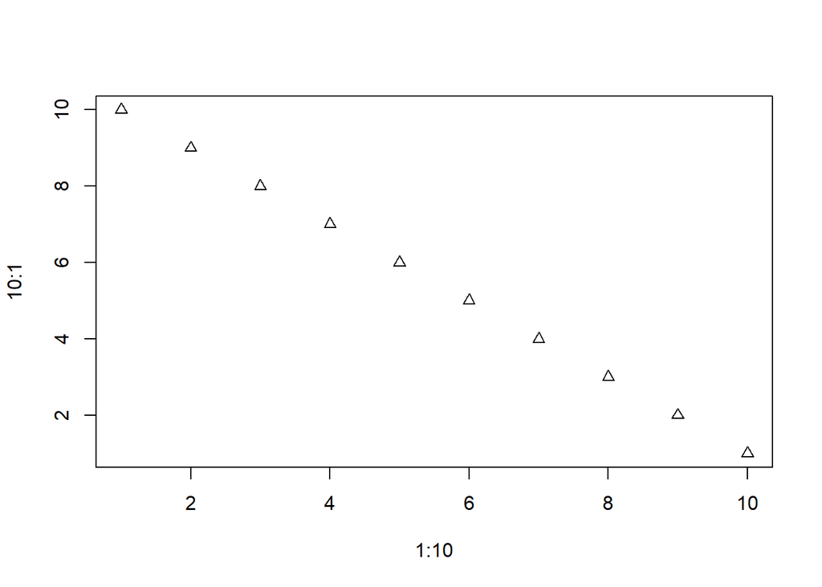

```r
plot(1:10,10:1,pch=2)
```

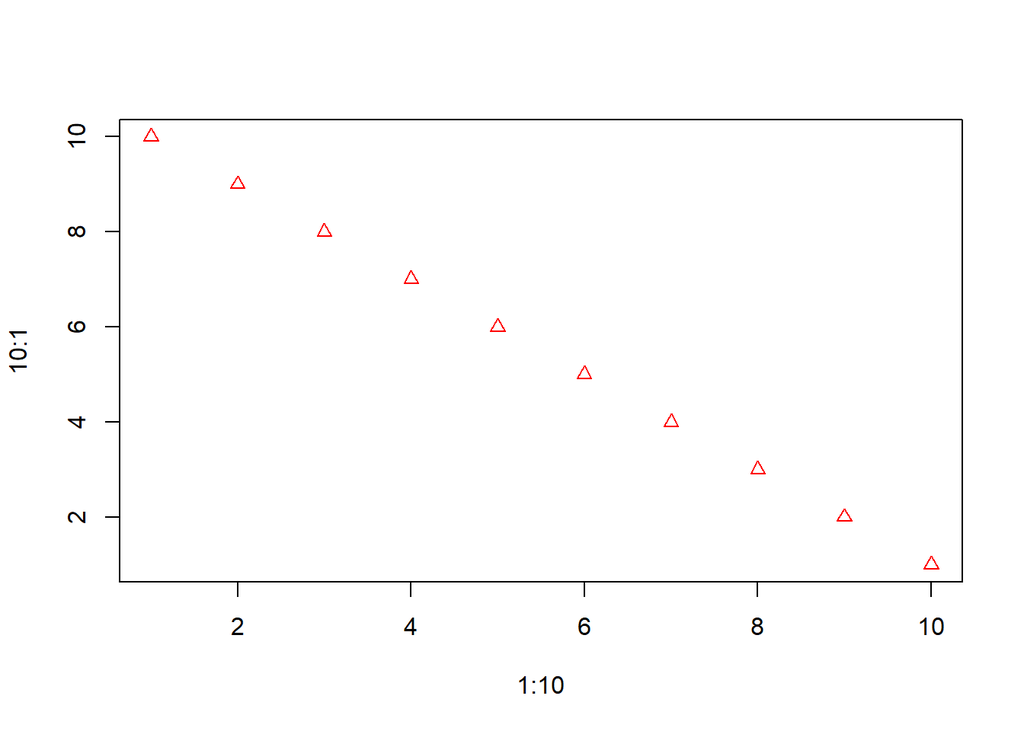

```r
plot(1:10,10:1,pch=2,col=2)
```

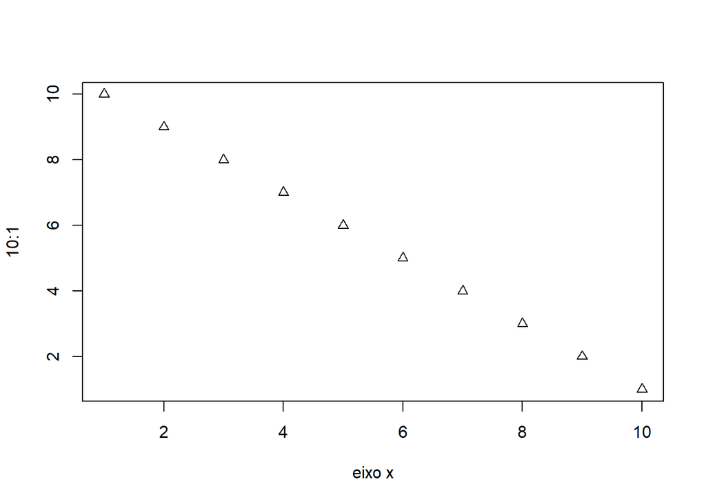

```r
plot(1:10,10:1,pch=2,xlab="eixo x")
```

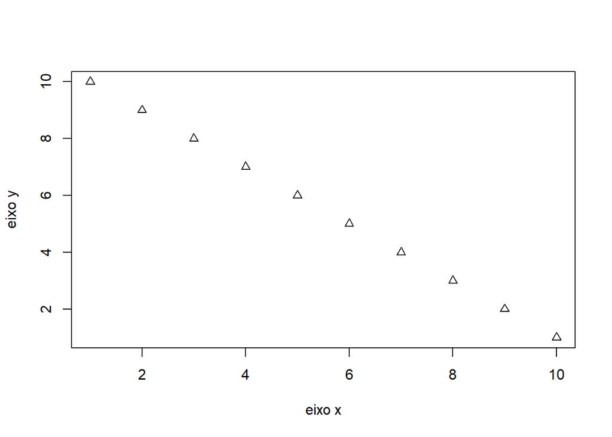

```r
plot(1:10,10:1,pch=2,xlab="eixo x",ylab="eixo y")
```

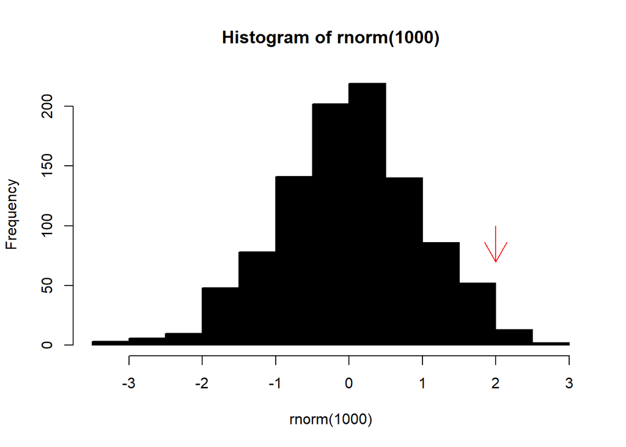

```r
hist(rnorm(1000),col=33)
arrows(2,100,2,70,col=2)
```

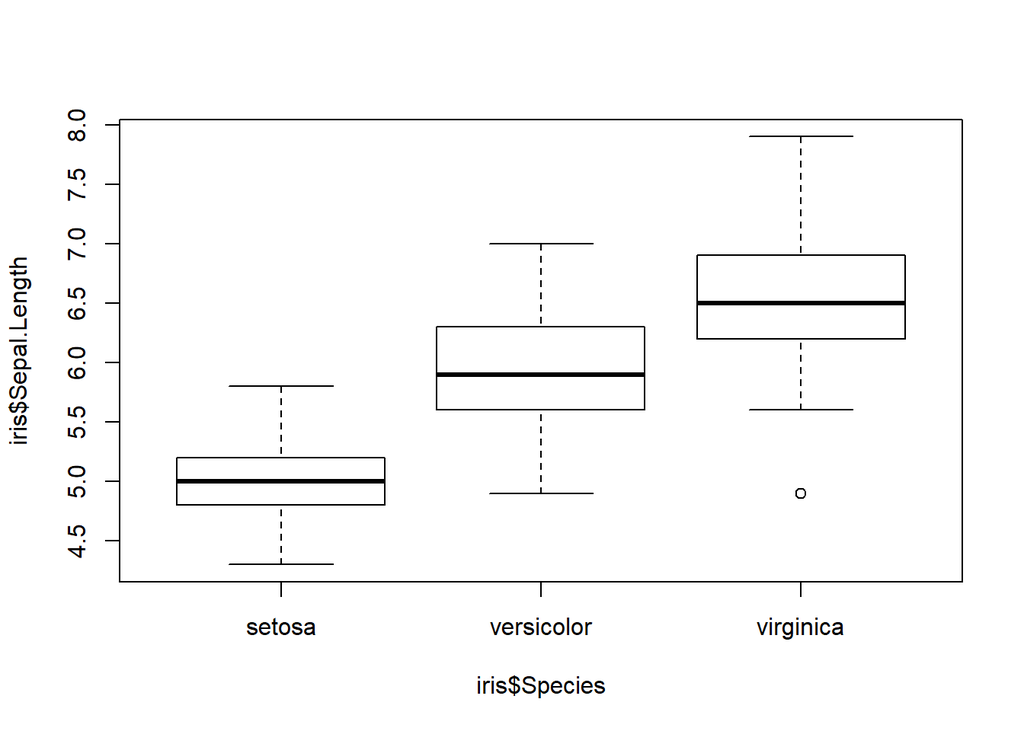

```r
boxplot(iris$Sepal.Length~iris$Species)
```

### Funções no R

Mais complicado, pois exige mais raciocinio logico na hora de montar a função que se adeque de fato ao seu objetivo.

```r
media=function(objeto){sum(objeto)/length(objeto)} # sum --> soma e Length --> quantidade
media(c(1,2,3))
```

```
## [1] 2
```

```r
alturas=c(1.4,1.7,2.0,1.6,1.8)
media(alturas)
```

```
## [1] 1.7
```

```r
#Fazendo soma, número de elementos e média separados

sum(alturas)    # soma dos elementos do objeto "alturas"
```

```
## [1] 8.5
```

```r
length(alturas) # número de elementos do objeto "alturas"
```

```
## [1] 5
```

```r
mean(alturas)   # média dos elementos do objeto "alturas"
```

```
## [1] 1.7
```

### Carregando Arquivos no R

São comandos que permitem a entrada de dados no R, sem precisar que estes sejam digitados todas as vezes que forem ser utilizados. Recomenda-se que as planilhas a serem importadas, estejam no formato csv.

Para definir o diretório que você está trabalhando:primeiro, verifique em que diretório o R está digitando getwd(). por padrão, no windows o diretório é a sua pasta documentos. para alterar isso, utilize o comando setwd()

```r
getwd()
```

```
## [1] "C:/Users/Bruna/Desktop/GIT/FIT678---Atividade-da-Aula-2"
```

```r
#setwd()

#Exemplo
#setwd("C:/meu_drive/meu_diretorio")
# O endereço do diretório tem de estar entre aspas, e as barras (“\”) tem de ser trocadas por barras invertidas(“/”). Após usar o comando acima, confira se funcionou usando o getwd(). você também pode alterar o diretório utilizando o menu Arquivo → Mudar dir
```

Além de salvar em CSV, deve-se separar os números decimais por ponto, uma vez que o R segue padrão americano.

Para pedir ao R que leia alguma arquivo usa-se o coamndo –> read.table() e guardamos o resultado em uma tabela. Exemplo:

```r
#read.table()
#tabela <- read.table(file="Dados.csv",header=T,sep=",")
# os dados estão no arquivo “Dados.csv”, que possui uma linha de cabeçalho com o nome das minhas colunas (“header=T”), e que minhas colunas são separadas por vígulas (sep=“,”).

#Se o arquivo não tiver cabeçalho, use header=F, e se suas colunas estiverem separador por outro símbolo, por exemplo ponto-e-vírgula, coloque o símbolo dentro das aspas do parâmetro sep (sep=“;”).
```